# Neal’s Funnel

**Author:** Jose Storopoli  
**Date:** Created on 09/03/2021. Updated on 09/03/2021

In this notebook we analyze Neal’s Funnel (Neal, 2011). Neal (2011) defines a distribution that exemplifies the difficulties of sampling from some hierarchical models. Neal’s example is fairly extreme, but can be trivially reparameterized in such a way as to make sampling straightforward. Neal’s example has support for $y \in \mathbb{R}$ and $x \in \mathbb{R}^9$ with density

$$p(y,x) = \text{Normal}(y \mid 0,3) \times
\prod_{n=1}^9
\text{normal}\left(x_n \mid 0,\exp\left(\frac{y}{2}\right)\right).$$

The probability contours are shaped like ten-dimensional funnels. The funnel’s neck is particularly sharp because of the exponential function applied to $y$. I won’t try to demonstrate it in 9 dimensions but I will show it in 3 dimensions. Below there is is the Neal’s Funnel density in 3-D. This is partially taken from a [StanCon 2018 YouTube video by Ben Goodrich](https://youtu.be/DPnLb5EaCkA?t=2700)[^1]

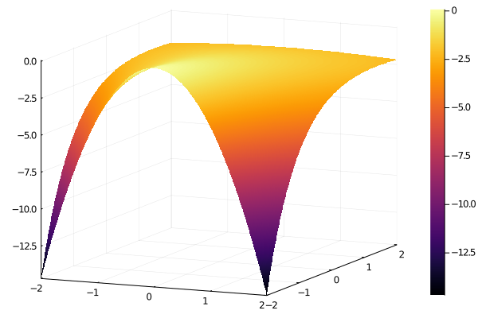

The Funnel

```julia
using Distributions, Plots

x = -2:0.01:2;
kernel(x, y) = logpdf(Normal(0, exp(y / 2)), x)
surface(x, x, kernel)
```

Below there is is the Neal’s Funnel reparameterized as standard normal density in 3-D.

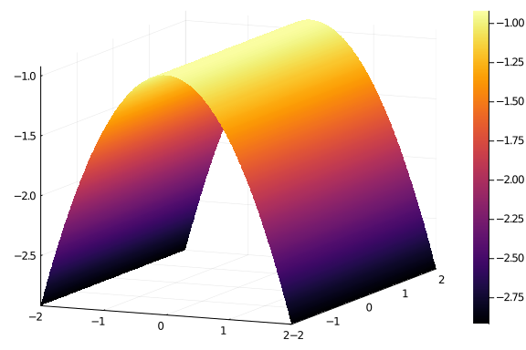

The Funnel Reparameterized

```julia
kernel_reparameterized(x, y) = logpdf(Normal(), x)
surface(x, x,  kernel_reparameterized)
```

# Environment

```julia
using InteractiveUtils
versioninfo()
```

```
Julia Version 1.6.0-rc1
Commit a58bdd9010* (2021-02-06 15:49 UTC)
Platform Info:
  OS: macOS (x86_64-apple-darwin20.3.0)
  CPU: Intel(R) Core(TM) i5-8500B CPU @ 3.00GHz
  WORD_SIZE: 64
  LIBM: libopenlibm
  LLVM: libLLVM-11.0.1 (ORCJIT, skylake)
Environment:
  JULIA_NUM_THREADS = 6
```

# References

Neal, R. M. (2011). MCMC using Hamiltonian dynamics. In S. Brooks, A. Gelman, G. L. Jones, & X.-L. Meng (Eds.), *Handbook of markov chain monte carlo*.

[^1]: see from 45’ onwards.
[^2]: this also works for multivariate distributions.

Published from using Weave.jl v0.10.7 on 2021-03-09.